Глава*5*

# Глава 5. Сети: основные понятия

Компьютерные сети позволяют пользователям совместно пользоваться ресурсами и обмениваться информацией. Можете ли вы представить мир без электронной почты, онлайн-газет, блогов, веб-сайтов и прочих сервисов, доступных через Интернет? Благодаря сетям пользователи могут также совместно пользоваться разными ресурсами, например, принтерами, приложениями, файлами, каталогами и дисковыми накопителями. В этой главе рассматриваются принципы и стандарты организации сетей, а также их назначение. ИТ-специалисты должны разбираться в основных сетевых понятиях, чтобы удовлетворять ожидания и потребности клиентов и пользователей сети.

Вы узнаете об основах проектирования сети и о том, как сетевые устройства влияют на передачу данных. К таким устройствам относятся концентраторы, коммутаторы, точки доступа, маршрутизаторы и межсетевые экраны. Здесь также рассматриваются различные типы подключений к сети Интернет, такие как DSL, кабельные линии, мобильный и спутниковый доступ. Вы узнаете о четырех уровнях модели TCP/IP, а также о функциях и протоколах, связанных с каждым из них. Вы также узнаете о различных беспроводных сетях и протоколах, в том числе о протоколах беспроводной сети LAN IEEE 802.11, о протоколах беспроводной связи на коротких расстояниях, включая RFID, NFC, и о стандартах протоколов для «умного дома», таких как Zigbee и Z-Wave. Эти знания помогут вам успешно проектировать, создавать и обслуживать сети. В конце главы мы обсудим различные типы сетевых кабелей: витую пару, волоконно-оптические и коаксиальные кабели. Вы узнаете о конструкции кабелей каждого типа, о способе передачи сигнала и о целесообразных вариантах их использования.

Важно получить не только теоретические знания о компьютерных сетях и их компонентов, но и приобрести практические навыки. При изучении этой главы вы сделаете и протестируете прямой кабель для сети Ethernet на базе неэкранированной витой пары (UTP).

# Сетевые значки

Сети представляют собой системы, образованные каналами. Компьютерные сети соединяют друг с другом различные устройства и пользователей. Для обозначения разных частей компьютерной сети используют различные значки.

## Узловые устройства

Сетевые устройства, знакомые большинству пользователей, называют оконечными или узловыми устройствами (рисунок 1). Их называют оконечными, поскольку такие устройства располагаются в конечных точках или на границе сети. Узловыми их называют из-за того, что они обычно на них установлены сетевые приложения, такие как веб-браузеры и почтовые клиенты, использующие сеть для предоставления различных услуг пользователям.

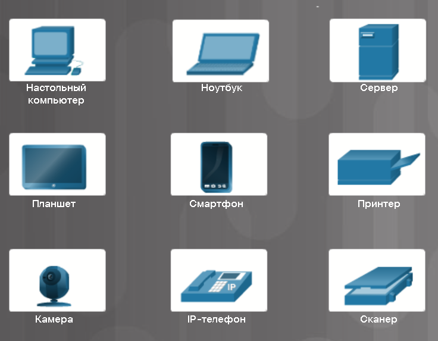

## Промежуточные устройства

Между узловыми устройствами в компьютерных сетях используется целый ряд других устройств. Такие промежуточные устройства обеспечивают обмен данными между узловыми устройствами. Наиболее распространенные промежуточные устройства показаны на рисунке 2.

- Коммутатор — подключает несколько устройств к сети.
- Маршрутизатор — пересылает трафик между сетями.
- Беспроводной маршрутизатор — подключает к сети несколько беспроводных устройств и может также содержать в себе коммутатор для подключения проводных устройств.
- Точка доступа (Access Point, AP) — подключается к беспроводному маршрутизатору и используется для расширения зоны покрытия беспроводной сети.
- Модем — подключает к сети Интернет домашнюю сеть или сеть небольшого офиса.

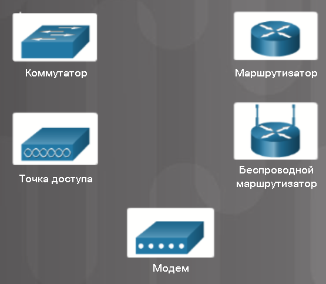